# Inserting R Code in Markdown

Richard Goodman

11 December 2020

# Importing and manipulating Data

First make sure there is a folder called data in your wd

Let us download the `gapminder_data.csv` dataset into our project

```r
download.file(url="https://raw.githubusercontent.com/cambiotraining/reproducibility-training/master/data/gapminder_data.csv", destfile="data/gapminder_data.csv")
```

Start to load the dataset

```r
# Load all libraries
library(tidyverse) # use for data manipulation and visualisation
library(kableExtra) # used for kbl()
library(rmarkdown) # used for paged_table function
library(ggpubr) #used for ggarrange function

# read file into R
pop_data = read_csv("data/gapminder_data.csv")

# create a table with data from Euro countries in 2007 - ordered by life expectancy
euro_data_tbl = pop_data %>%
  # Filter by continent and year
  filter(continent == "Europe" & year == 2007) %>%
  # remove continent and year (since they are all the same)
  select(-continent, -year) %>%
  # arrange by life expecntancy
  arrange(desc(lifeExp)) %>%
  # Rename columns names to how we want them
  rename(Country = country,
         "Population size" = pop,
         "Life Expectancy" = lifeExp,
         "GDP" = gdpPercap)
```

# Tables in R Markdown

We will use the `kableExtra` package to design some tables. The vignette for kableExtra can be found [here](https://cran.r-project.org/web/packages/kableExtra/vignettes/awesome_table_in_html.html)

The results in euro_data_tbl are displayed in the table below:

```r
euro_data_tbl %>%
  kbl() %>%
  kable_styling(bootstrap_options = c("striped", full_width = F)) %>%
                  scroll_box(width = "100%", height = "200px" )
```

| Country | Population size | Life Expectancy | GDP |
| --- | --- | --- | --- |
| Iceland | 301931 | 81.757 | 36180.789 |
| Switzerland | 7554661 | 81.701 | 37506.419 |
| Spain | 40448191 | 80.941 | 28821.064 |
| Sweden | 9031088 | 80.884 | 33859.748 |
| France | 61083916 | 80.657 | 30470.017 |
| Italy | 58147733 | 80.546 | 28569.720 |
| Norway | 4627926 | 80.196 | 49357.190 |
| Austria | 8199783 | 79.829 | 36126.493 |
| Netherlands | 16570613 | 79.762 | 36797.933 |
| Greece | 10706290 | 79.483 | 27538.412 |
| Belgium | 10392226 | 79.441 | 33692.605 |
| United Kingdom | 60776238 | 79.425 | 33203.261 |
| Germany | 82400996 | 79.406 | 32170.374 |
| Finland | 5238460 | 79.313 | 33207.084 |
| Ireland | 4109086 | 78.885 | 40675.996 |
| Denmark | 5468120 | 78.332 | 35278.419 |
| Portugal | 10642836 | 78.098 | 20509.648 |
| Slovenia | 2009245 | 77.926 | 25768.258 |
| Czech Republic | 10228744 | 76.486 | 22833.309 |
| Albania | 3600523 | 76.423 | 5937.030 |
| Croatia | 4493312 | 75.748 | 14619.223 |
| Poland | 38518241 | 75.563 | 15389.925 |
| Bosnia and Herzegovina | 4552198 | 74.852 | 7446.299 |
| Slovak Republic | 5447502 | 74.663 | 18678.314 |
| Montenegro | 684736 | 74.543 | 9253.896 |
| Serbia | 10150265 | 74.002 | 9786.535 |
| Hungary | 9956108 | 73.338 | 18008.944 |
| Bulgaria | 7322858 | 73.005 | 10680.793 |
| Romania | 22276056 | 72.476 | 10808.476 |
| Turkey | 71158647 | 71.777 | 8458.276 |

A better way to display long tables is using the function `paged_table()` in the `rmarkdown` library can be used to do this

```r
paged_table(euro_data_tbl)
```

| Country | Population size | Life Expectancy | GDP |
| --- | --- | --- | --- |
| Iceland | 301931 | 81.757 | 36180.789 |
| Switzerland | 7554661 | 81.701 | 37506.419 |
| Spain | 40448191 | 80.941 | 28821.064 |
| Sweden | 9031088 | 80.884 | 33859.748 |
| France | 61083916 | 80.657 | 30470.017 |
| Italy | 58147733 | 80.546 | 28569.720 |
| Norway | 4627926 | 80.196 | 49357.190 |
| Austria | 8199783 | 79.829 | 36126.493 |
| Netherlands | 16570613 | 79.762 | 36797.933 |
| Greece | 10706290 | 79.483 | 27538.412 |

[output cut: 20 more lines]

# Adding images

Adding images is straightforward and does not require using a specific R Markdown function.

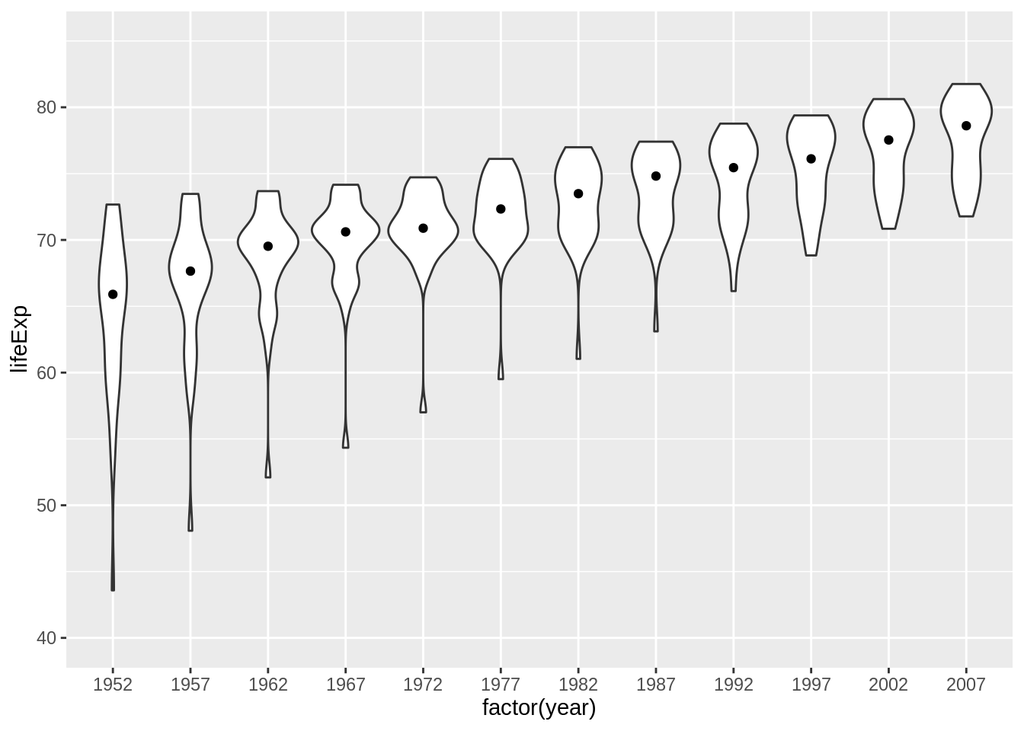

```r
euro_plot = pop_data %>%
  filter(continent == "Europe") %>%
  select(-continent) %>%
  # Add factor() to ensure year is treated as discrete
  ggplot(aes(x = factor(year), y = lifeExp)) +
  # use geom_violin
  geom_violin() +
  # plot the median as a point on the violin
  stat_summary(fun = median, geom = "point") +
  ylim(40, 85)

# display plot
euro_plot
```

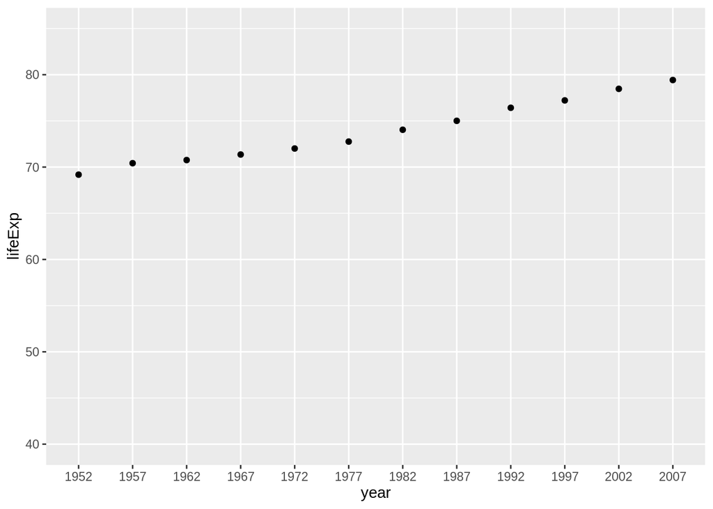

```r
uk_plot = pop_data %>%
  # filter for United Kingdom
  filter(country == "United Kingdom") %>%
  # use mutate to convert year to factor
  mutate(year = as_factor(year)) %>%
  # Plot a scatterplot with geom_point
  ggplot(aes(x = year, y = lifeExp)) +
  geom_point() +
  ylim(40, 85)

# display plot
uk_plot
```

ggarrage() is a function present in the ggpubr pacakge that can place two or more figures next to each other

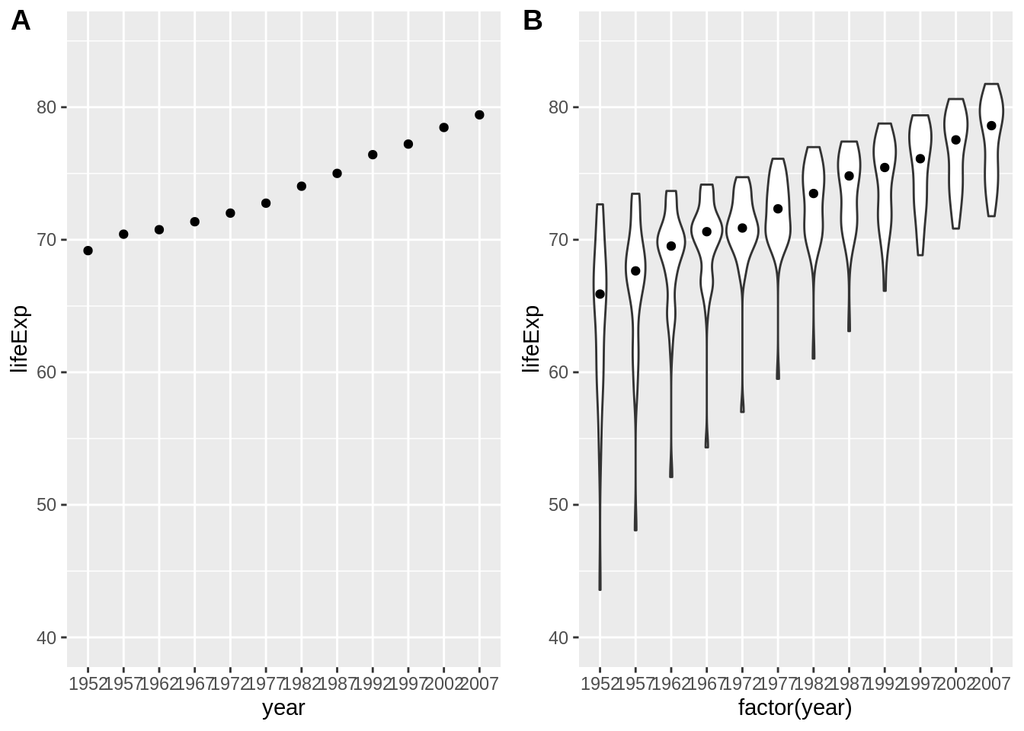

```r
# Use ggarrange to arrange the uk_plot and euro_plot
ggarrange(uk_plot, euro_plot, ncol = 2, nrow = 1, labels = c("A", "B"))
```

# Send to Github

First render files to publish files in Github using the follwoing commands

`rmarkdown::render("inserting-code-in-rmarkdown.Rmd")` `rmarkdown::render("index.Rmd")`

To download git first go to [here](https://support.rstudio.com/hc/en-us/articles/200532077-Version-Control-with-Git-and-SVN)

1. Then click Tools > Version Control > Project set up Git
2. If asked whether you want to initialise a new Git repository for this project, click Yes.
3. If asked whether RStudio needs to be restarted, click Yes.
4. Next we need to configure Git. Go to Tools > Shell. This should take you to the Terminal window in RStudio. Make sure you are first in the working directory of your project (use getwd() to check that). Then set the Git username and email using the following two commands:

```
git config --global user.name "yourGitHubUsername"
git config --gloabl user.email "name@provider.com"
```

5. Next create a repository in GitHub.
6. After you click on the Create repository button, a Quick setup page is displayed which provides code for different scenarios. Copy the first line of the “…or push an existing repository from the command line” section and run it in the RStudio terminal. The line of code should look something like this: `git remote add origin https://github.com/Another-Goodman/R-Markdown-Basics.git`
7. From the Git tab in RStudio, select the files you would like to commit to GitHub.
8. Press the Commit button, enter a commit message and then press the Commit button in the new pop-up commit window.